# DeepDDS on TDC DrugComb: A Reproducible Graph + Attention Synergy Baseline

Daniel R. Russell | Env: Python 3.11.14 · PyTorch 2.5.1+cu121 · PyG 2.7.0 · RDKit 2023.9.6 · PyTDC 1.1.15 · AWS EC2 (NVIDIA A10G) | SNPTX EXP-01

This experiment reproduces the molecular graph encoders and attention-fusion block of DeepDDS (Wang et al. 2022) in a graph-only setting. The framework code it depends on (the DrugComb adapter, molecular graph construction, compound filters, GNN and attention modules, and the deterministic setup) is vendored in this repositry under `src/` and imported as the `snptx` package. The repository is self-contained: cloning it and following the setup cells below is sufficient to run the notebook end-to-end and reproduce the reported metrics.

The notebook loads the Therapeutics Data Commons DrugComb release (297,098 pairwise screens), trains on a class-balanced 9,576-row subset, compares the graph model with a Morgan fingerprint random forest, and writes a JSON metrics record under `results/metrics/`. The full DeepDDS formulation also incorporates cell-line or gene-expression context; this first experiment intentionally leaves that channel out so the molecular-graph contribution and its limitations are visible.

Sections

1. Environment and imports  
2. System architecture and methodology  
3. Data loading: TDC DrugComb (Parquet snapshot)  
4. Preprocessing: compound filters and graphs  
5. Model: dual GNN with cross-drug attention  
6. Training: AdamW with CosineLR, 30 epochs

7. Held-out evaluation and JSON record  
8. Morgan fingerprint and random forest baseline  
9. Embedding geometry, attention, and pair-held-out diagnostic  
10. Synopsis  
11. References

Source: snptx1/snptx-repro-deepdds (self-contained public reproduction; framework code vendored under `src/`)  
Module: `snptx.models.drug_synergy.DeepDDSModel`  
Video: [Long-form presentation](https://youtu.be/_EoqyNVWaJc) · [Brief overview](https://youtu.be/QwPEQp_xu9s)  
Setup: the next two code cells locate the project root (cloning the repository on first run if needed), put the vendored `src/` directory on `sys.path`, and install any missing dependencies into the active kernel interpreter via `sys.executable -m pip install`.

## 1. Environment and Configuration

The framework code this notebook depends on is vendored in this repo under `src/` and imported as the `snptx` package; nothing needs to be installed from PyPI separately. The next two code cells make that work end-to-end: the first locates the project root (cloning the public reproduction repo), and the second puts `src/` on `sys.path` and installs any still-missing third-party dependancies into the active kernel interpreter.

```python
"""
Locate the snptx-repro-deepdds project root. If the notebook is launched
outside an existing checkout, clone the public reproduction repo 1x.
"""

import os
import shutil
import subprocess
from pathlib import Path

REPO_URL = "https://github.com/snptx1/snptx-repro-deepdds.git"
CHECKOUT_DIR_NAME = "snptx-repro-deepdds"
PROJECT_MARKERS = ("Makefile", "notebooks", "repro_deepdds.py")


def _is_project_root(path: Path) -> bool:
    return all((path / marker).exists() for marker in PROJECT_MARKERS)


here = Path.cwd().resolve()
project_root = next((p for p in (here, *here.parents) if _is_project_root(p)), None)

if project_root is None:
    if shutil.which("git") is None:
        raise SystemExit("git is required to bootstrap the repository but was not found on PATH.")
    checkout_dir = here / CHECKOUT_DIR_NAME
    if not checkout_dir.exists():
        print(f"Cloning {REPO_URL} into {checkout_dir} ...")
        subprocess.check_call(["git", "clone", "--depth", "1", REPO_URL, str(checkout_dir)])
    project_root = checkout_dir.resolve()
    if not _is_project_root(project_root):
        raise SystemExit(f"Expected experiment directory not found at {project_root}.")

os.chdir(project_root)
print(f"project root: {project_root}")
print(f"cwd         : {Path.cwd()}")
```

```
Cloning https://github.com/snptx1/snptx-repro-deepdds.git into /home/snptx/snptx-repro-deepdds ...
```

```
Cloning into '/home/snptx/snptx-repro-deepdds'...
```

```
project root: /home/snptx/snptx-repro-deepdds
cwd         : /home/snptx/snptx-repro-deepdds
```

```python
from __future__ import annotations

import gc
import importlib
import importlib.util
import json
import os
import subprocess
import sys
from pathlib import Path

NOTEBOOK_NAME = 'EXP_01_DeepDDS_Drug_Synergy_Prediction.ipynb'
START_DIR = Path.cwd().resolve()

# Locate the project root from the cwd.
_project_candidates: list[Path] = []
for base in (START_DIR, *START_DIR.parents):
    _project_candidates.extend([
        base,
        base / 'snptx-repro-deepdds',
        base / 'snptx-academic' / 'snptx-repro-deepdds',
    ])
PROJECT_DIR = next(
    (path.resolve() for path in _project_candidates if (path / 'notebooks' / NOTEBOOK_NAME).exists()),
    None,
)
if PROJECT_DIR is None:
    raise FileNotFoundError(
        'Could not locate the snptx-repro-deepdds project directory. '
        'Run this notebook from within a clone of snptx-repro-deepdds.'
    )
NOTEBOOK_DIR = PROJECT_DIR / 'notebooks'
os.chdir(NOTEBOOK_DIR)

for sub in ('data/raw', 'results/metrics', 'results/figures', 'assets'):
    (PROJECT_DIR / sub).mkdir(parents=True, exist_ok=True)

# Prefer the vendored public package
_VENDORED_SRC = str((PROJECT_DIR / 'src').resolve())
if _VENDORED_SRC not in sys.path:
    sys.path.insert(0, _VENDORED_SRC)

# Map import names to pip specs.
REQUIRED_PACKAGES: dict[str, str] = {
    'numpy': 'numpy>=1.26,<2',
    'pandas': 'pandas>=2.0,<3',
    'pyarrow': 'pyarrow>=14',
    'matplotlib': 'matplotlib>=3.7',
    'PIL': 'Pillow',
    'IPython': 'ipython>=8',
    'sklearn': 'scikit-learn>=1.3,<2',
    'rdkit': 'rdkit==2023.9.6',
    'tdc': 'PyTDC==1.1.15',
    'torch': 'torch==2.5.1',
    'torch_geometric': 'torch-geometric==2.7.0',
}


def _pip_install(spec: str) -> None:
    print(f'[setup] installing {spec}')
    subprocess.check_call([sys.executable, '-m', 'pip', 'install', '--quiet', spec])


missing = [pkg for mod, pkg in REQUIRED_PACKAGES.items() if importlib.util.find_spec(mod) is None]
for spec in missing:
    _pip_install(spec)
if missing:
    importlib.invalidate_caches()

still_missing = [mod for mod in REQUIRED_PACKAGES if importlib.util.find_spec(mod) is None]
if still_missing:
    raise ModuleNotFoundError(
        'Missing required notebook dependencies after install attempt: '
        + ', '.join(still_missing)
    )

import matplotlib.pyplot as plt
import numpy as np
import pandas as pd
import torch
import torch.nn.functional as F
from torch.optim import AdamW
from torch.optim.lr_scheduler import CosineAnnealingLR
from torch.utils.data import DataLoader
from torch_geometric.data import Batch

import snptx
import snptx.viz.theme as vu
from snptx.repro import seed_worker, set_seed, snapshot_env


def project_relative(path: Path) -> str:
    try:
        return str(path.resolve().relative_to(PROJECT_DIR))
    except ValueError:
        return str(path)


SEED = 42
set_seed(SEED)
DEVICE = torch.device('cuda' if torch.cuda.is_available() else 'cpu')
GENERATOR = torch.Generator().manual_seed(SEED)

print('snptx    :', snptx.__version__)
print('python   :', sys.version.split()[0])
print('torch    :', torch.__version__)
print('device   :', DEVICE, '|',
      torch.cuda.get_device_name(0) if torch.cuda.is_available() else 'cpu only')
print('project  :', PROJECT_DIR)
print('notebook :', NOTEBOOK_DIR)
print('snptx pkg:', Path(snptx.__file__).resolve().parent)
```

```
snptx    : 0.1.0
python   : 3.11.14
torch    : 2.5.1+cu121
device   : cuda | NVIDIA A10G
project  : /home/snptx/snptx-academic/snptx-repro-deepdds
notebook : /home/snptx/snptx-academic/snptx-repro-deepdds/notebooks
snptx pkg: /home/snptx/snptx-core/src/snptx
```

## 2. System Architecture and Methodology

The diagram below traces the experiment from raw TDC records to held-out metrics. Raw DrugComb rows are canonicalized by `DrugCombAdapter`, SMILES strings are parsed into molecular graphs, paired graphs enter two weight-sharing GNN branches, and a cross-drug attention block fuses the two embeddings around a learnable `[FUSE]` token before classification. Each box names a concrete `snptx` symbol used later in the notebook.

The design isolates the molecular-structure channel of DeepDDS, records the consequences of training on a class-balanced subset, compares the learned representation with a strong Morgan fingerprint baseline, and explicitly distinguishes row-level generalization from pair-held-out drug-pair discovery. That distinction matters because DrugComb contains repeated measurements of the same unordered drug pair across different cell lines.

[figure not shown]

The data path is explicit. Raw TDC data flows left to right through ingestion and preprocesing, branches into the two molecular-graph encoders, converges at the `[FUSE]` token attention block, and exits as a predicted synergy probability. The blue and purple data boxes correspond to sections 3 and 4, the orange model lane to sections 5 and 6, and the green evaluation lane to sections 7 through 9.

## 3. Data Loading: TDC DrugComb

The DrugComb release distributed by TDC contains 297,098 paired drug measurements across cancer cell lines and five synergy scoring conventions: CSS, ZIP, Bliss, Loewe, and HSA. Following Wang et al. (2022), Loewe synergy is treated as the supervised endpoint and binarized at the threshold of 10. The full table is loaded once through `DrugCombAdapter`, reduced to five canonical columns, and cached as Parquet so later runs do not depend on the TDC CDN or on upstream schema drift.

```python
"""
Load the full DrugComb table with on-disk Parquet caching:

DrugCombAdapter wraps PyTDC.multi_pred.DrugSyn, renames the raw columns
(Drug1, Drug2, Cell_Line_ID, Synergy_Loewe) into the snptx
schema (drug1_smiles, drug2_smiles, cell_line, synergy_score), and adds
the binary synergy_label column at the requested threshold.
"""

from snptx.adapters.drugcomb import DrugCombAdapter  # pyright: ignore[reportMissingImports]

try:
    import importlib.metadata as _ilm
    TDC_VERSION = _ilm.version('PyTDC')
except Exception:
    TDC_VERSION = 'unknown'

raw_dir = PROJECT_DIR / 'data' / 'raw'
raw_dir.mkdir(parents=True, exist_ok=True)
cache_path = raw_dir / f'drugcomb_tdc_v{TDC_VERSION}.parquet'
CANONICAL_COLS = ['drug1_smiles', 'drug2_smiles', 'cell_line', 'synergy_score', 'synergy_label']

from typing import cast as _cast

df_full: pd.DataFrame
if cache_path.exists():
    df_full = _cast(pd.DataFrame, pd.read_parquet(cache_path))
    print(f'loaded cached snapshot: {project_relative(cache_path)}  ({len(df_full):,} rows)')
else:
    adapter = DrugCombAdapter(raw_dir=raw_dir)
    df_full_raw = adapter.build('drug_synergy', source='tdc', synergy_threshold=10.0)
    df_full = _cast(pd.DataFrame, df_full_raw[CANONICAL_COLS].copy())
    df_full.to_parquet(cache_path, index=False)
    print(f'wrote cached snapshot: {project_relative(cache_path)}  ({len(df_full):,} rows)')

# Re-instantiate the adapter on cache hits so build_pair_dataset is avail later.
adapter = DrugCombAdapter(raw_dir=raw_dir)

print(f'Full DrugComb table: {len(df_full):,} rows')
print(f'Class distribution : {pd.Series(df_full["synergy_label"]).value_counts().to_dict()}')
print(f'Loewe score range  : [{df_full["synergy_score"].min():.1f}, {df_full["synergy_score"].max():.1f}]')
print(f'Loewe median       : {float(pd.Series(df_full["synergy_score"]).median()):.2f}')
print(f'Cell lines         : {pd.Series(df_full["cell_line"]).nunique()}')
df_full.head(3)
```

```
loaded cached snapshot: data/raw/drugcomb_tdc_v1.1.15.parquet  (297,098 rows)
Full DrugComb table: 297,098 rows
Class distribution : {0: 292310, 1: 4788}
Loewe score range  : [-116.6, 86.7]
Loewe median       : -4.64
Cell lines         : 59
```

|  | drug1_smiles | drug2_smiles | cell_line | synergy_score | synergy_label |
| --- | --- | --- | --- | --- | --- |
| 0 | CCCCCOC(=O)NC1=NC(=O)N(C=C1F)C2C(C(C(O2)C)O)O | CC1C(C(CC(O1)OC2CC(CC3=C2C(=C4C(=C3O)C(=O)C5=C... | 786-0 | -25.305263 | 0 |
| 1 | CCCCCOC(=O)NC1=NC(=O)N(C=C1F)C2C(C(C(O2)C)O)O | CC1C(C(CC(O1)OC2CC(CC3=C2C(=C4C(=C3O)C(=O)C5=C... | A498 | -30.431910 | 0 |
| 2 | CCCCCOC(=O)NC1=NC(=O)N(C=C1F)C2C(C(C(O2)C)O)O | CC1C(C(CC(O1)OC2CC(CC3=C2C(=C4C(=C3O)C(=O)C5=C... | A549 | -32.889290 | 0 |

```python
"""
Build a class-balanced subsample:

Synergistic pairs are roughly 1.6 percent of the full table at the Loewe
threshold of 10. Drawing every positive row plus a matched negative sample
creates a 50/50 learning signal.
"""

from typing import cast as _cast

pos = _cast(pd.DataFrame, df_full[df_full['synergy_label'] == 1])
neg = _cast(pd.DataFrame, df_full[df_full['synergy_label'] == 0]).sample(n=len(pos), random_state=SEED)

df = pd.concat([pos, neg]).sample(frac=1.0, random_state=SEED).reset_index(drop=True)

print(f'Balanced sample : {len(df):,} rows ({len(pos):,} positive, {len(neg):,} negative)')
_n_uniq = len(set(df['drug1_smiles']).union(df['drug2_smiles']))
print(f'Unique SMILES   : {_n_uniq:,}')
print(f'Cell lines      : {df["cell_line"].nunique()}')
```

```
Balanced sample : 9,576 rows (4,788 positive, 4,788 negative)
Unique SMILES   : 125
Cell lines      : 59
```

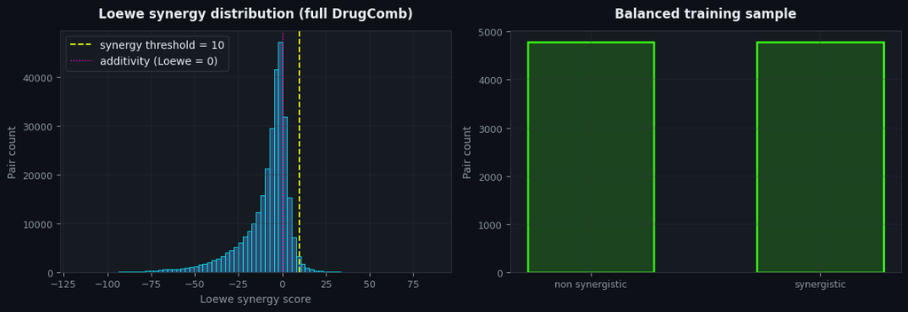

```python
# Vis the raw Loewe dist and balanced class counts.
fig, axes = plt.subplots(1, 2, figsize=(12, 4.2))
fig.set_facecolor(vu.DARK_BG)

# Full-table Loewe histogram with ref lines for synergy and additivity.
axes[0].hist(df_full['synergy_score'], bins=80,
             color=vu.hex_to_rgba(vu.ACCENT_BLUE, 0.35),
             edgecolor=vu.NEON_BLUE, linewidth=0.6)
axes[0].axvline(10.0, color=vu.NEON_YELLOW, linestyle='--',
                linewidth=1.4, label='synergy threshold = 10')
axes[0].axvline(0.0, color=vu.NEON_PINK, linestyle=':',
                linewidth=1.0, label='additivity (Loewe = 0)')
axes[0].set_xlabel('Loewe synergy score')
axes[0].set_ylabel('Pair count')
vu.apply_dark_theme(axes[0], title='Loewe synergy distribution (full DrugComb)')
vu.dark_legend(axes[0], loc='upper left')

# Pos and neg counts in the balanced training subset.
counts = df['synergy_label'].value_counts().sort_index()
vu.dark_bar(axes[1], np.arange(2), counts.values,
            color=vu.NEON_GREEN, neon=vu.NEON_GREEN, width=0.55)
axes[1].set_xticks([0, 1])
axes[1].set_xticklabels(['non synergistic', 'synergistic'])
axes[1].set_ylabel('Pair count')
vu.apply_dark_theme(axes[1], title='Balanced training sample')

plt.tight_layout()
plt.show()
```

## 4. Preprocessing: Compound Filters and Graph Construction

Drug-likeness filters describe the chemcal space the model is asked to learn. Lipinski's rule of five (Lipinski et al. 1997) summarizes common oral-drug ranges for molecular weight, logP, and hydrogen-bond counts; PAINS filters (Baell and Holloway 2010) flag motifs associated with assay interference; REOS and Glaxo lead-like filters impose stricter physicochemical constraints. These filters aren't usedto exclude rows from training here. They are reported to contextualize the compounds in the balanced subset and to make clear whether the GNN is learning mostly conventional drug-like chemistry or a more heterogeneous screening space.

```python
# Apply four standard drug-likeness filters to every unique SMILES.
from snptx.preprocessing.compound_filters import filter_compound

# Deduplicate compounds so each molecule is counted once per filter.
unique_smiles = pd.concat([df['drug1_smiles'], df['drug2_smiles']]).unique()

filter_records = [filter_compound(str(s)) for s in unique_smiles]
filter_summary = pd.DataFrame([
    {'lipinski': r.passes_lipinski, 'pains': r.passes_pains,
     'reos': r.passes_reos, 'glaxo': r.passes_glaxo, 'all': r.passes_all}
    for r in filter_records
])

# Boolean column means are pass rates.
pass_rates: pd.Series = pd.Series(filter_summary.mean()).round(3)
print(f'Unique SMILES filtered: {len(filter_summary)}')
print('Pass rates:')
print(pass_rates.to_string())
```

```
Unique SMILES filtered: 125
Pass rates:
lipinski    0.808
pains       0.872
reos        0.416
glaxo       0.384
all         0.240
```

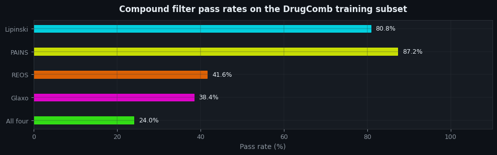

```python
# Plot compound filter pass rates.
fig, ax = plt.subplots(figsize=(10, 3.2))
fig.set_facecolor(vu.DARK_BG)
ax.set_facecolor(vu.DARK_BG)

names = ['Lipinski', 'PAINS', 'REOS', 'Glaxo', 'All four']
values = np.asarray(pass_rates.values, dtype=float) * 100
neons = [vu.NEON_BLUE, vu.NEON_YELLOW, vu.NEON_ORANGE, vu.NEON_PINK, vu.NEON_GREEN]
y_pos = np.arange(len(names))

for y, v, c in zip(y_pos, values, neons):
    ax.barh(y, v, color=c, height=0.32, edgecolor=c, linewidth=0.8, alpha=0.85)
    ax.text(v + 1.2, y, f'{v:.1f}%', color=vu.TEXT_PRIMARY,
            va='center', fontsize=9, fontfamily=vu.GH_FONT)

ax.set_yticks(y_pos)
ax.set_yticklabels(names, color=vu.TEXT_PRIMARY, fontfamily=vu.GH_FONT, fontsize=9.5)
ax.invert_yaxis()
ax.set_xlim(0, 110)
ax.set_xlabel('Pass rate (%)')
vu.apply_dark_theme(ax, title='Compound filter pass rates on the DrugComb training subset')
plt.tight_layout()
plt.show()
```

PAINS remains relatively permissive on this frozen DrugComb subset, with 109 of 125 unique compounds passing (87.2%), which is consistent with a data collection that avoids many classic assay-interference motifs. Lipinski passes 101 of 125 compounds (80.8%), while the stricter lead-likeness filters pass fewer molecules: REOS passes 52 of 125 (41.6%) and the Glaxo rule passes 48 of 125 (38.4%). Only 30 of 125 compounds pass all four filters (24%), so we can deduce the combind pass rate is governed by the stricter REOS and Glaxo cutoffs rather than by the broader or more permissive PAINS screen.

### 4.1 SMILES to Graph Conversion and Train / Validation / Test Split

With the chemistry profile established, every SMILES string is converted into a PyTorch Geometric `Data` graph by `DrugCombAdapter.build_pair_dataset`. The adapter caches per-molecule graphs so RDKit parsing happens once per unique compound, and it returns `(graph_a, graph_b, label)` tuples that the dataloader can consume directly. The saved run produced 9,576 valid graph pairs, then used a 70 / 15 / 15 row-level random split with 6,703 training pairs, 1,436 validation pairs, and 1,437 held-out test pairs. Section 9.1 later audits the consequence of this row-level split for repeated drug pairs.

```python
"""
Materialize molecular graph pairs and create row-level splits.

Atom feature dimension is 9 and edge feature dimension is 3, as defined
by DrugCombAdapter.smiles_to_graph. The internal graph cache means RDKit
parses each unique SMILES 1x across all drug pairs.
"""

pairs = adapter.build_pair_dataset(df)
print(f'Total valid graph pairs: {len(pairs):,}')

# Seeded row-level 70/15/15 split (Section 9.1 audits repeated pair keys).
perm = np.random.default_rng(SEED).permutation(len(pairs))
n_train = int(0.7 * len(pairs))
n_val = int(0.15 * len(pairs))
train_idx = perm[:n_train]
val_idx = perm[n_train:n_train + n_val]
test_idx = perm[n_train + n_val:]

train_pairs = [pairs[i] for i in train_idx]
val_pairs = [pairs[i] for i in val_idx]
test_pairs = [pairs[i] for i in test_idx]
print(f'Split: train={len(train_pairs):,}  val={len(val_pairs):,}  test={len(test_pairs):,}')
```

```
Total valid graph pairs: 9,576
Split: train=6,703  val=1,436  test=1,437
```

```python
# Batch paired graphs through separate PyG Batch objects.
def collate_pairs(batch):
    g_a = Batch.from_data_list([b[0] for b in batch])
    g_b = Batch.from_data_list([b[1] for b in batch])
    y = torch.cat([b[2] for b in batch]).long()
    return g_a, g_b, y


BATCH = 64

# Pyright expects Dataset objects, but DataLoader supprts lists with a custom collate function.
from typing import cast
from torch.utils.data import Dataset

_train_ds = cast(Dataset, train_pairs)
_val_ds = cast(Dataset, val_pairs)
_test_ds = cast(Dataset, test_pairs)

train_loader = DataLoader(_train_ds, batch_size=BATCH, shuffle=True,
                          collate_fn=collate_pairs, generator=GENERATOR,
                          worker_init_fn=seed_worker, num_workers=0)
val_loader = DataLoader(_val_ds, batch_size=BATCH, shuffle=False,
                        collate_fn=collate_pairs, num_workers=0)
test_loader = DataLoader(_test_ds, batch_size=BATCH, shuffle=False,
                         collate_fn=collate_pairs, num_workers=0)
print(f'batch size: {BATCH}')
```

```
batch size: 64
```

## 5. Model Architecture

`DeepDDSModel` composes three reusable `snptx` primitives. Two parallel graph neural networks, instantiated through `snptx.models.gnn.build_gnn_model`, encode each molecule into a fixed-dimnsional graph embedding by global pooling. A `CrossDrugAttention` module fuses the two graph embeddings around a learned `[FUSE]` token, following the Transformer self-attention pattern introduced by Vaswani et al. (2017). A compact MLP (Multi-Layer Perceptron) head then emits two logits for the binary synergy classification task.

The original DeepDDS paper uses paired molecular structure together with cell-line context. This EXP-01 model preserves the dual graph branches and attention fusion while omitting cell-line features, so it should more or less be read as the molecular-graph subset of the full architecture. Weight sharng between the two branches is kept asthe default, which treats the two input drugs as molecules drawn from the same feature space rather than as seperate modalities.

```python
# Instantiate the DeepDDS model on the active device and report its size.
from snptx.models.drug_synergy import DeepDDSModel

model = DeepDDSModel(
    atom_feature_dim=9,
    hidden_channels=128,
    gnn_type='gcn',
    gnn_layers=3,
    attention_heads=4,
    attention_layers=2,
    dropout=0.3,
    num_classes=2,
    share_branch_weights=True,
).to(DEVICE)

n_params = sum(p.numel() for p in model.parameters())
print(f'Total trainable parameters: {n_params:,}')
```

```
Total trainable parameters: 456,642
```

## 6. Training

Optimization uses AdamW with weight decay $10^{-4}$ and a cosine annealing schedule over thirty epochs. Batches of sixty-four drug pairs fit easily in 24 GB of A10G VRAM with gradient checkpointing disabled. Cross entropy is reported on the training and validation splits at every epoch, and validation AUROC is tracked on the same cadence. The goal is *not* to tune until the GNN beats every baseline; it is to produce a stable graph-only DeepDDS receipt and then test whether that receipt survives comparison with a simpler fingerprint model.

```python
"""
Train the model and collect validation metrics.

step_loader runs one full pass over a dataloader. In training mode it
backpropagates cross entropy and steps the optimizer; in evaluation mode
it disables gradients and returns probs and labels for metrics.
"""

from IPython.display import display
from sklearn.metrics import roc_auc_score

EPOCHS = 30
optim = AdamW(model.parameters(), lr=5e-4, weight_decay=1e-4)
sched = CosineAnnealingLR(optim, T_max=EPOCHS)


# Run one dataloader pass and return mean loss, P(synergy), and targets.
def step_loader(loader, train: bool):
    model.train(train)
    losses, preds, ys = [], [], []
    for g_a, g_b, y in loader:
        g_a = g_a.to(DEVICE)
        g_b = g_b.to(DEVICE)
        y = y.to(DEVICE)
        with torch.set_grad_enabled(train):
            logits = model(g_a.x, g_a.edge_index, g_a.batch,
                           g_b.x, g_b.edge_index, g_b.batch)
            loss = F.cross_entropy(logits, y)
            if train:
                optim.zero_grad()
                loss.backward()
                optim.step()
        losses.append(float(loss.detach().cpu()))
        preds.append(F.softmax(logits.detach(), dim=-1)[:, 1].cpu().numpy())
        ys.append(y.detach().cpu().numpy())
    return float(np.mean(losses)), np.concatenate(preds), np.concatenate(ys)


history = {'train_loss': [], 'val_loss': [], 'val_auroc': []}
training_checkpoints = []
for epoch in range(1, EPOCHS + 1):
    tl, _, _ = step_loader(train_loader, train=True)
    vl, vp, vy = step_loader(val_loader, train=False)
    sched.step()
    val_auroc = roc_auc_score(vy, vp) if len(set(vy)) > 1 else float('nan')
    history['train_loss'].append(tl)
    history['val_loss'].append(vl)
    history['val_auroc'].append(val_auroc)
    if epoch == 1 or epoch % 5 == 0 or epoch == EPOCHS:
        training_checkpoints.append({
            'epoch': epoch,
            'train_loss': tl,
            'val_loss': vl,
            'val_auroc': val_auroc,
        })

training_checkpoints_df = pd.DataFrame(training_checkpoints)
display(
    training_checkpoints_df
    .style.hide(axis='index')
    .format({
        'epoch': '{:d}',
        'train_loss': '{:.4f}',
        'val_loss': '{:.4f}',
        'val_auroc': '{:.3f}',
    })
    .set_caption('Training checkpoints')
)
```

Training checkpoints

| epoch | train_loss | val_loss | val_auroc |
| --- | --- | --- | --- |
| 1 | 0.6623 | 0.6711 | 0.740 |
| 5 | 0.5890 | 0.5581 | 0.784 |
| 10 | 0.5654 | 0.5590 | 0.797 |
| 15 | 0.5570 | 0.5310 | 0.808 |
| 20 | 0.5430 | 0.5373 | 0.806 |
| 25 | 0.5412 | 0.5311 | 0.811 |
| 30 | 0.5344 | 0.5342 | 0.810 |

[figure not shown]

```python
# Plot training loss and validation AUROC curves.
fig, axes = plt.subplots(1, 2, figsize=(12, 4))
fig.set_facecolor(vu.DARK_BG)

epochs_axis = np.arange(1, len(history['train_loss']) + 1)

axes[0].plot(epochs_axis, history['train_loss'], color=vu.ACCENT_BLUE,
             linewidth=1.6, label='train')
axes[0].plot(epochs_axis, history['val_loss'], color=vu.NEON_YELLOW,
             linewidth=1.6, label='val')
axes[0].set_xlabel('Epoch')
axes[0].set_ylabel('Cross entropy loss')
vu.apply_dark_theme(axes[0], title='Loss curves')
vu.dark_legend(axes[0])

axes[1].plot(epochs_axis, history['val_auroc'], color=vu.ACCENT_GREEN, linewidth=1.6)
axes[1].axhline(0.80, color=vu.TEXT_SECONDARY, linestyle='--',
                linewidth=1.0, label='0.80 reference')
axes[1].set_xlabel('Epoch')
axes[1].set_ylabel('Validation AUROC')
axes[1].set_ylim(0.45, 1.0)
vu.apply_dark_theme(axes[1], title='Validation AUROC across training')
vu.dark_legend(axes[1], loc='lower right')

plt.tight_layout()
plt.show()
```

## 7. Held-Out Test Evaluation

The test split was untouched during training and validation. Evaluating on it once estimates how the trained graph-only DeepDDS model generalizes to held-out rows from the same DrugComb-derived distribution. The split is *row-level random* rather than pair-held-out: because DrugComb measures the same unordered drug pair across multiple cell lines, the exact two-drug combination in a test row may also appear in a different training row at a different cell line. Rebuilding the partition by unordered drug pair bef ore training would be required for a strict pair-held-out estimate. Section 9.1 audits that distinction directly.

Three metrics are reported: AUROC, accuracy, and F1. The ROC curve summarizes threshold-independent ranking, while the confusion matrix shows behavior at the default 0.5 threshold. Headline values are serialized to a JSON record under `results/metrics/` with a runtime env snapshot for reproducibility.

```python
# Compute held-out metrics from one inference pass and persist them.
from IPython.display import Markdown, display
from sklearn.metrics import (accuracy_score, confusion_matrix, f1_score,
                              roc_auc_score, roc_curve)

_, p_test, y_test = step_loader(test_loader, train=False)
y_hat = (p_test > 0.5).astype(int)
auroc = roc_auc_score(y_test, p_test)
acc = accuracy_score(y_test, y_hat)
f1 = f1_score(y_test, y_hat, zero_division=0)  # type: ignore[arg-type]
val_auroc_final = float(history['val_auroc'][-1])

metrics_dir = PROJECT_DIR / 'results' / 'metrics'
metrics_dir.mkdir(parents=True, exist_ok=True)
result = {
    'experiment': 'EXP-01 DeepDDS Drug Synergy (graph-only)',
    'seed': SEED,
    'device': str(DEVICE),
    'test_auroc': float(auroc),
    'test_acc': float(acc),
    'test_f1': float(f1),
    'val_auroc_final': val_auroc_final,
    'epochs': EPOCHS,
    'n_train': len(train_pairs),
    'n_val': len(val_pairs),
    'n_test': len(test_pairs),
    'env': snapshot_env(),
}
out_path = metrics_dir / ('deepdds_result_gpu.json' if DEVICE.type == 'cuda' else 'deepdds_result_cpu.json')
out_path.write_text(json.dumps(result, indent=2))

display(Markdown(
    f'**Headline metrics (graph-only DeepDDS, seed {SEED}, device {DEVICE}).** '
    f'Test AUROC **{auroc:.3f}**, accuracy **{acc:.3f}**, F1 **{f1:.3f}**; '
    f'final validation AUROC **{val_auroc_final:.3f}**. '
    f'Metrics record written to `{project_relative(out_path)}`.'
))
```

**Headline metrics (graph-only DeepDDS, seed 42, device cuda).** Test AUROC **0.786**, accuracy **0.706**, F1 **0.680**; final validation AUROC **0.810**. Metrics record written to `results/metrics/deepdds_result_gpu.json`.

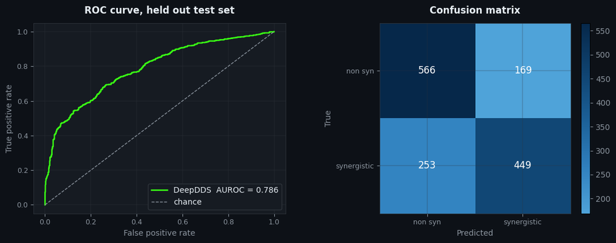

```python
# Plot ROC curve and confusion matrix for the held-out test set.
fpr, tpr, _ = roc_curve(y_test, p_test)
cm = confusion_matrix(y_test, y_hat, labels=[0, 1])

fig, axes = plt.subplots(1, 2, figsize=(11, 4.4))
fig.set_facecolor(vu.DARK_BG)

axes[0].plot(fpr, tpr, color=vu.NEON_GREEN, linewidth=1.8,
             label=f'DeepDDS  AUROC = {auroc:.3f}')
axes[0].plot([0, 1], [0, 1], color=vu.TEXT_SECONDARY,
             linestyle='--', linewidth=1.0, label='chance')
axes[0].set_xlabel('False positive rate')
axes[0].set_ylabel('True positive rate')
vu.apply_dark_theme(axes[0], title='ROC curve, held out test set')
vu.dark_legend(axes[0], loc='lower right')

im = axes[1].imshow(cm, cmap=vu.SNPTX_HEAT)
axes[1].set_xticks([0, 1])
axes[1].set_yticks([0, 1])
axes[1].set_xticklabels(['non syn', 'synergistic'])
axes[1].set_yticklabels(['non syn', 'synergistic'])
for (i, j), v in np.ndenumerate(cm):
    axes[1].text(j, i, str(v), ha='center', va='center',
                  color='white', fontsize=12, fontfamily=vu.GH_FONT)
cb = fig.colorbar(im, ax=axes[1], fraction=0.045, pad=0.04)
cb.ax.tick_params(colors=vu.TEXT_SECONDARY)
vu.apply_dark_theme(axes[1], title='Confusion matrix')
axes[1].set_xlabel('Predicted')
axes[1].set_ylabel('True')

plt.tight_layout()
plt.show()
```

## 8. Baseline Comparison: Morgan Fingerprints with a Random Forest

A fingerprint baseline is the appropriate sanity check for any GNN result on small-molecule data. Morgan circular fingerprints (Rogers and Hahn 2010) at radius 2 with 1,024 bits encode local atom neighborhoods, and they oftn remain competitive with learned molecular representations. Concatenating both drug fingerprints and fitting a 200-tree random forest gives a transparent baseline on the same train and test rows. The GNN shld outperform or at least explain its gap to this baseline before the extra model complexity can be justified.

```python
# Train a Morgan fingerprint + random forest baseline on the same split.
from rdkit import Chem  # type: ignore[import-untyped]
from rdkit.Chem import AllChem  # type: ignore[import-untyped]
from sklearn.ensemble import RandomForestClassifier


# Return a radius-2 Morgan bit vector, using zeros for unparsable SMILES.
def fingerprint(smiles: str, n_bits: int = 1024) -> np.ndarray:
    mol = Chem.MolFromSmiles(smiles)
    if mol is None:
        return np.zeros(n_bits, dtype=np.uint8)
    bv = AllChem.GetMorganFingerprintAsBitVect(mol, radius=2, nBits=n_bits)
    return np.array(bv, dtype=np.uint8)


X_full = np.stack([
    np.concatenate([fingerprint(str(r['drug1_smiles'])), fingerprint(str(r['drug2_smiles']))])
    for _, r in df.iterrows()
])
y_full = df['synergy_label'].values

X_tr, X_te = X_full[train_idx], X_full[test_idx]
y_tr, y_te = y_full[train_idx], y_full[test_idx]

rf = RandomForestClassifier(n_estimators=200, n_jobs=-1, random_state=SEED).fit(X_tr, y_tr)
p_rf = rf.predict_proba(X_te)[:, 1]
rf_auroc = roc_auc_score(y_te, p_rf)
print(f'Random Forest baseline AUROC = {rf_auroc:.3f}')
print(f'DeepDDS AUROC                = {auroc:.3f}')
print(f'Delta (DeepDDS - RF)         = {auroc - rf_auroc:+.3f}')
```

```
Random Forest baseline AUROC = 0.856
DeepDDS AUROC                = 0.786
Delta (DeepDDS - RF)         = -0.070
```

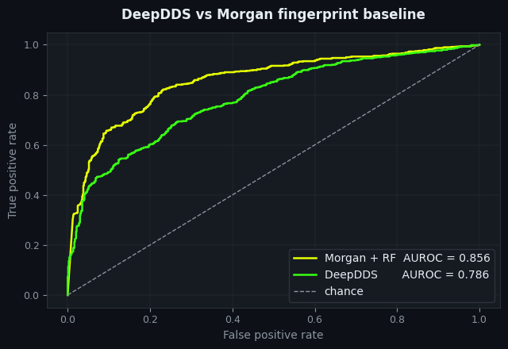

```python
# Compare DeepDDS + Morgan + random forest ROC curves.
fpr_rf, tpr_rf, _ = roc_curve(y_te, p_rf)
fig, ax = plt.subplots(figsize=(6.5, 4.5))
fig.set_facecolor(vu.DARK_BG)
ax.plot(fpr_rf, tpr_rf, color=vu.NEON_YELLOW, linewidth=1.8,
        label=f'Morgan + RF  AUROC = {rf_auroc:.3f}')
ax.plot(fpr, tpr, color=vu.NEON_GREEN, linewidth=1.8,
        label=f'DeepDDS       AUROC = {auroc:.3f}')
ax.plot([0, 1], [0, 1], color=vu.TEXT_SECONDARY, linestyle='--',
        linewidth=1.0, label='chance')
ax.set_xlabel('False positive rate')
ax.set_ylabel('True positive rate')
vu.apply_dark_theme(ax, title='DeepDDS vs Morgan fingerprint baseline')
vu.dark_legend(ax, loc='lower right')
plt.tight_layout()
plt.show()
```

On this class-balanced subset of DrugComb, the Morgan plus random forest baseline reaches AUROC 0.856, while graph-only DeepDDS reaches 0.786, a delta of -0.070 in favor of the fingerprint baseline. This is an important methodological result - the learned graph representation is not automatically superior when the model is denied cell-line context.

Three factors plausibly explain the gap. First, the balanced subset reducex the training set from 297,098 rows to 6,703 training examples, which is exactly the regime in which circular fingerprints can remain highly competitive (Yang et al. 2019). Second, this experiment intentionally omits the cell-line conditioning channel used by the full DeepDDS architecture, so the model cannot represent context-specific synergy. Third, the random forest receives a 2,048-dimensional fingerprint per pair, while the GNN must learn atom-level representations from limited supervised data. Training on the full table, adding a learned cell-line embedding, and pretraining the GNN encoders on larger molecule corpora are the natural follow-on experiments.

## 9. Embedding Geometry and Attention

Two visualizations probe what the model has learned. A t-SNE projection of the test-set drug-pair embeddings asks whether the GNN places synergistic and non-synergistic rows into locally distinguishable regions of representation space. A heatmap of the cross-drug attention weights asks how info is routed among the learned `[FUSE]` token and the two drug tokens at inference time.

The representations below are used for simple diagnostics. The t-SNE panel can reveal local structure, but it cannot prove class separation or prospective discovery value. Likewise, attention weights show how tokens communicate inside this model, but they do not by themselves identify causal chemical substructures. The idea here is to try connect the scalar metrics to the learned representation.

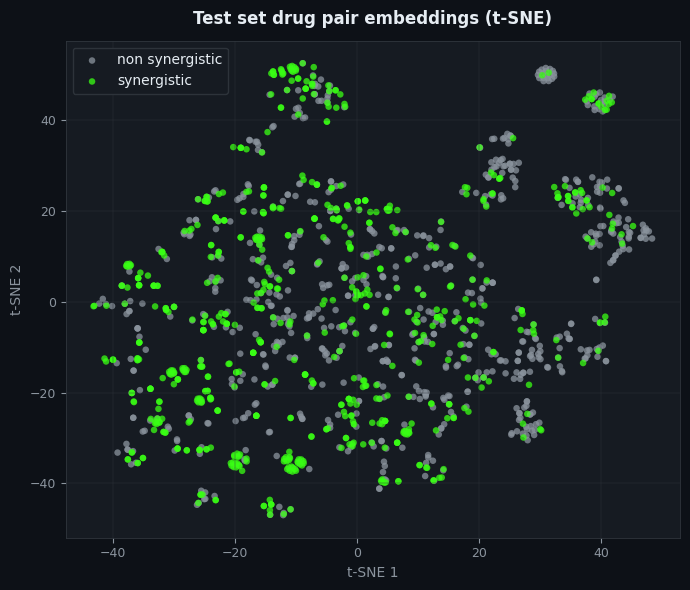

```python
"""
Collect test-set pair embeddings and project them with t-SNE.

Each test pair is run through the model in inference mode. The concatenated
branch embeddings returned by get_attention_weights form the represntation
matrix projected below.
"""
from typing import cast
from sklearn.manifold import TSNE

model.eval()
embs, labs = [], []
with torch.no_grad():
    for g_a, g_b, y in test_loader:
        g_a = g_a.to(DEVICE)
        g_b = g_b.to(DEVICE)
        info = model.get_attention_weights(g_a.x, g_a.edge_index, g_a.batch,
                                            g_b.x, g_b.edge_index, g_b.batch)
        _ea = cast(torch.Tensor, info['emb_a'])
        _eb = cast(torch.Tensor, info['emb_b'])
        e = torch.cat([_ea, _eb], dim=-1).cpu().numpy()
        embs.append(e)
        labs.append(y.numpy())
embs = np.concatenate(embs)
labs = np.concatenate(labs).astype(int)

coords = TSNE(n_components=2, perplexity=min(30, len(embs) // 4 + 1),
              random_state=SEED, init='random').fit_transform(embs)

fig, ax = plt.subplots(figsize=(7, 6))
fig.set_facecolor(vu.DARK_BG)
for cls, color, name in [(0, vu.TEXT_SECONDARY, 'non synergistic'),
                          (1, vu.NEON_GREEN, 'synergistic')]:
    mask = labs == cls
    ax.scatter(coords[mask, 0], coords[mask, 1], c=color,
               s=22, alpha=0.75, edgecolor='none', label=name)
ax.set_xlabel('t-SNE 1')
ax.set_ylabel('t-SNE 2')
vu.apply_dark_theme(ax, title='Test set drug pair embeddings (t-SNE)')
vu.dark_legend(ax, loc='best')
plt.tight_layout()
plt.show()
```

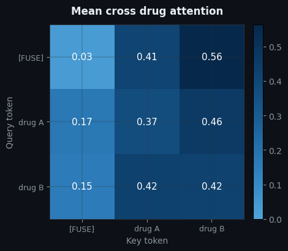

```python
"""
Avg attention tensors over one held-out mini-batch.

The attention module receives three tokens per pair: a learned fusion token,
the drug A graph embedding, and the drug B graph embedding. Averaging layers
and batch members gives a compact token-level summary.
"""
with torch.no_grad():
    g_a, g_b, _ = next(iter(test_loader))
    g_a = g_a.to(DEVICE)
    g_b = g_b.to(DEVICE)
    info = model.get_attention_weights(g_a.x, g_a.edge_index, g_a.batch,
                                       g_b.x, g_b.edge_index, g_b.batch)

attn_layers = [tensor.detach().cpu().numpy() for tensor in info['attention_weights']]
avg = np.stack(attn_layers).mean(axis=(0, 1))

fig, ax = plt.subplots(figsize=(4.8, 4.2))
fig.set_facecolor(vu.DARK_BG)
im = ax.imshow(avg, cmap=vu.SNPTX_HEAT, vmin=0)

labels_axis = ['[FUSE]', 'drug A', 'drug B']
ax.set_xticks(range(3))
ax.set_yticks(range(3))
ax.set_xticklabels(labels_axis)
ax.set_yticklabels(labels_axis)

for (i, j), v in np.ndenumerate(avg):
    ax.text(j, i, f'{v:.2f}', ha='center', va='center',
             color='white', fontsize=11, fontfamily=vu.GH_FONT)
cb = fig.colorbar(im, ax=ax, fraction=0.045, pad=0.04)
cb.ax.tick_params(colors=vu.TEXT_SECONDARY)
vu.apply_dark_theme(ax, title='Mean cross drug attention')
ax.set_xlabel('Key token')
ax.set_ylabel('Query token')
plt.tight_layout()
plt.show()

_ = gc.collect()
torch.cuda.empty_cache()
```

The t-SNE projection is a check on the learned pair embeddings: synergistic and non-synergistic points occupy structured regions but overlap substantially, so the plot is prob not a substitute for the held-out metrics in section 7. The attention heatmap is also diagnostic in that it shows the saved model routing information through the `[FUSE]` token and both drug tokens, which is consistent with the dual-branch design, but it doesn't establish which chemical features drove each prediction.

### 9.1 Top pair-held-out drug-pair predictions (error analysis 1.0)

A model with a strong row-level AUROC is not yet a useful discovery tool unless its highest-confidence predictions are chemically plausible. The row-level random split used in this experiment can place repeated measurements of the same unordered drug pair in diff splits, because DrugComb contains the same combination across several cell lines. The diagnostic below therefore collapses the test set to *unique* unordered drug pairs and, where enough examples are available, restricts the visualized candidates to pairs absent from both the training and val splits.

Each table row is one unordered drug pair from the test split, ranked by the model's mean predicted synergy probability across that pair's held-out test rows. `pair_split_status` compares the sorted SMILES pair key against the training and validation pair keys; `not seen in train/val` means the exact two-drug combination was notused during model fitting or model selection, although either single compound may still appear in other pairs. `positive_rate` is the observed held-out label fraction for the displayed pair, not the model score. Most displayed pairs have one held-out cell-line row, so a value of `0.00` means the observed held-out row was non-synergistic at the Loewe threshold and `1.00` means it was synergistic.

Note that, by way of contrast, a defensible pair-held-out evaluation would require rebuilding the train, validation, and test partitions by `pair_key` before training, then reporting top-k precision and calibration on that split.

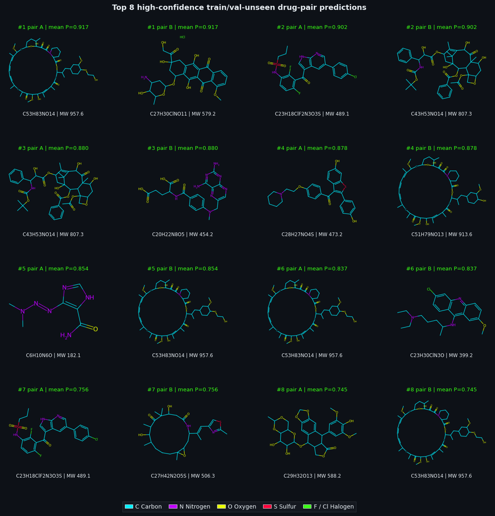

| rank | pair_split_status | p_syn_mean | p_syn_max | positive_rate | heldout_rows | heldout_cell_lines | median_loewe | max_loewe | representative_cell_line | compound_A | compound_B |
| --- | --- | --- | --- | --- | --- | --- | --- | --- | --- | --- | --- |
| 1 | not seen in train/val | 0.917 | 0.917 | 0.00 | 1 | 1 | 3.0 | 3.0 | NCI-H322M | C53H83NO14 \| MW 957.6 | C27H30ClNO11 \| MW 579.2 |
| 2 | not seen in train/val | 0.902 | 0.902 | 1.00 | 1 | 1 | 11.3 | 11.3 | HT29 | C23H18ClF2N3O3S \| MW 489.1 | C43H53NO14 \| MW 807.3 |
| 3 | not seen in train/val | 0.880 | 0.880 | 0.00 | 2 | 2 | -3.7 | 1.3 | IGROV1 | C43H53NO14 \| MW 807.3 | C20H22N8O5 \| MW 454.2 |
| 4 | not seen in train/val | 0.878 | 0.878 | 0.00 | 1 | 1 | -10.4 | -10.4 | RPMI-8226 | C28H27NO4S \| MW 473.2 | C51H79NO13 \| MW 913.6 |
| 5 | not seen in train/val | 0.854 | 0.854 | 0.00 | 1 | 1 | -31.3 | -31.3 | SK-MEL-2 | C6H10N6O \| MW 182.1 | C53H83NO14 \| MW 957.6 |
| 6 | not seen in train/val | 0.837 | 0.837 | 0.00 | 1 | 1 | -13.1 | -13.1 | MCF7 | C53H83NO14 \| MW 957.6 | C23H30ClN3O \| MW 399.2 |
| 7 | not seen in train/val | 0.756 | 0.756 | 0.00 | 1 | 1 | -8.9 | -8.9 | SN12C | C23H18ClF2N3O3S \| MW 489.1 | C27H42N2O5S \| MW 506.3 |
| 8 | not seen in train/val | 0.745 | 0.745 | 0.00 | 1 | 1 | 0.4 | 0.4 | NCIH23 | C29H32O13 \| MW 588.2 | C53H83NO14 \| MW 957.6 |

```
Displayed 8 unique test-set drug-pair predictions ranked by mean predicted P(synergy).
Selection: restricted to drug pairs absent from both training and validation.
Observed labels: 1/8 pairs have at least one synergistic held-out cell-line row.
Descriptive pair hit rate: 0.12; this is not prospective precision.
Mean observed held-out positive rate: 0.12.
Pair-held-out diagnostic: 1068 unique test pairs.
248 were absent from both training and validation.
```

```python
# Render the top 8 high-confidence pair-held-out drug-pair predictions.
import PIL.Image as PILImage
from io import BytesIO
from IPython.display import display
from matplotlib.patches import Patch
from rdkit import Chem
from rdkit.Chem import AllChem
from rdkit.Chem.Draw import rdMolDraw2D
from rdkit.Chem.rdMolDescriptors import CalcExactMolWt, CalcMolFormula

# Step 1: rerun inference on the test loader to gather per-pair P(synergy).
model.eval()
probs_all, labels_all = [], []
with torch.no_grad():
    for g_a, g_b, y in test_loader:
        g_a = g_a.to(DEVICE)
        g_b = g_b.to(DEVICE)
        logits = model(g_a.x, g_a.edge_index, g_a.batch, g_b.x, g_b.edge_index, g_b.batch)
        probs_all.append(torch.softmax(logits, dim=1)[:, 1].cpu().numpy())
        labels_all.append(y.numpy())
probs_all = np.concatenate(probs_all)
labels_all = np.concatenate(labels_all)

# Step 2: collapse rows to unordered drug-pair keys and tag split provenance.
def _pair_key(drug_a: object, drug_b: object) -> tuple[str, str]:
    return tuple(sorted((str(drug_a), str(drug_b))))


def _split_pair_keys(indices: np.ndarray) -> set[tuple[str, str]]:
    split_frame = df.iloc[indices][['drug1_smiles', 'drug2_smiles']]
    return {_pair_key(a, b) for a, b in zip(split_frame['drug1_smiles'], split_frame['drug2_smiles'])}


train_pair_keys = _split_pair_keys(train_idx)
val_pair_keys = _split_pair_keys(val_idx)


def _pair_split_status(pair_key: tuple[str, str]) -> str:
    if pair_key in train_pair_keys:
        return 'seen in train'
    if pair_key in val_pair_keys:
        return 'seen in val only'
    return 'not seen in train/val'


# Step 3: combine test metadata, predictions, labels, and pair keys.
test_pairs_df = df.iloc[test_idx][['drug1_smiles', 'drug2_smiles', 'cell_line', 'synergy_score']].reset_index(drop=True)
scored_rows = test_pairs_df.copy()
scored_rows['p_syn'] = probs_all
scored_rows['y_true'] = labels_all.astype(int)
scored_rows['pair_key'] = [_pair_key(a, b) for a, b in zip(scored_rows['drug1_smiles'], scored_rows['drug2_smiles'])]

# Step 4: chem helpers for molecule metadata.
def _compound_meta(smi: str) -> tuple[str, str, str]:
    mol = Chem.MolFromSmiles(smi)
    if mol is None:
        short_smi = smi[:34] + ('...' if len(smi) > 34 else '')
        return 'unparsed molecule', 'MW n/a', short_smi
    formula = CalcMolFormula(mol)
    mw = CalcExactMolWt(mol)
    short_smi = smi[:34] + ('...' if len(smi) > 34 else '')
    return formula, f'MW {mw:.1f}', short_smi


def _atom_numbers(smi: str) -> set[int]:
    mol = Chem.MolFromSmiles(smi)
    if mol is None:
        return set()
    return {atom.GetAtomicNum() for atom in mol.GetAtoms()}


def _draw_molecule(smi: str, size: tuple[int, int] = (360, 280)) -> PILImage.Image:
    mol = Chem.MolFromSmiles(smi)
    if mol is None:
        return PILImage.new('RGB', size, color=vu.DARK_BG)
    AllChem.Compute2DCoords(mol)  # type: ignore[attr-defined]
    drawer = rdMolDraw2D.MolDraw2DCairo(size[0], size[1])
    opts = drawer.drawOptions()
    opts.setBackgroundColour(tuple(c / 255 for c in (0x0d, 0x11, 0x17)) + (1.0,))
    opts.bondLineWidth = 1.7
    opts.updateAtomPalette({
        6: (0.00, 0.94, 1.00),
        7: (0.75, 0.00, 1.00),
        8: (0.90, 1.00, 0.00),
        9: (0.22, 1.00, 0.08),
        15: (1.00, 0.43, 0.00),
        16: (1.00, 0.00, 0.24),
        17: (0.22, 1.00, 0.08),
    })
    drawer.DrawMolecule(mol)
    drawer.FinishDrawing()
    return PILImage.open(BytesIO(drawer.GetDrawingText()))


# Step 5: summarize each unordered drug pair over its held-out test rows.
pair_records = []
for pair_key, group in scored_rows.groupby('pair_key', sort=False):
    representative = group.sort_values(['p_syn', 'synergy_score'], ascending=[False, False]).iloc[0]
    pair_records.append({
        'pair_key': pair_key,
        'drug1_smiles': str(representative['drug1_smiles']),
        'drug2_smiles': str(representative['drug2_smiles']),
        'representative_cell_line': str(representative['cell_line']),
        'p_syn_mean': float(group['p_syn'].mean()),
        'p_syn_max': float(group['p_syn'].max()),
        'positive_rate': float(group['y_true'].mean()),
        'n_rows': int(len(group)),
        'n_cell_lines': int(group['cell_line'].nunique()),
        'median_loewe': float(group['synergy_score'].median()),
        'max_loewe': float(group['synergy_score'].max()),
        'pair_split_status': _pair_split_status(pair_key),
    })

# Step 6: prefer train/validation-unseen pairs when enough exist.
pair_summary = pd.DataFrame(pair_records).sort_values(
    ['p_syn_mean', 'p_syn_max', 'n_cell_lines'], ascending=[False, False, False]
).reset_index(drop=True)
n_show = min(8, len(pair_summary))
unseen_mask = pair_summary['pair_split_status'].eq('not seen in train/val')
unseen_pair_summary = pair_summary[unseen_mask].copy()
if len(unseen_pair_summary) >= n_show:
    ranking_pool = unseen_pair_summary
    selection_label = 'train/validation-unseen'
    selection_note = 'restricted to drug pairs absent from both training and validation'
else:
    ranking_pool = pair_summary
    selection_label = 'unique'
    selection_note = 'drawn from all unique test drug pairs because fewer than eight train/validation-unseen pairs were available'
top_unique_pairs = ranking_pool.head(n_show).copy()
title_selection_label = 'train/val-unseen' if selection_label == 'train/validation-unseen' else 'unique test-set'

# Step 7: build table rows and grid entries for the figure.
grid_entries, top_rows = [], []
present_atomic_nums: set[int] = set()
for rank, row in enumerate(top_unique_pairs.itertuples(index=False), start=1):
    smi_a = str(row.drug1_smiles)
    smi_b = str(row.drug2_smiles)
    present_atomic_nums.update(_atom_numbers(smi_a))
    present_atomic_nums.update(_atom_numbers(smi_b))
    formula_a, mw_a, short_a = _compound_meta(smi_a)
    formula_b, mw_b, short_b = _compound_meta(smi_b)
    top_rows.append({
        'rank': rank,
        'pair_split_status': row.pair_split_status,
        'p_syn_mean': row.p_syn_mean,
        'p_syn_max': row.p_syn_max,
        'positive_rate': row.positive_rate,
        'heldout_rows': row.n_rows,
        'heldout_cell_lines': row.n_cell_lines,
        'median_loewe': row.median_loewe,
        'max_loewe': row.max_loewe,
        'representative_cell_line': row.representative_cell_line,
        'compound_A': f'{formula_a} | {mw_a}',
        'compound_B': f'{formula_b} | {mw_b}',
        'smiles_A': short_a,
        'smiles_B': short_b,
    })
    grid_entries.extend([
        {'rank': rank, 'label': 'A', 'p_syn_mean': row.p_syn_mean,
         'formula': formula_a, 'mw': mw_a, 'smiles': smi_a},
        {'rank': rank, 'label': 'B', 'p_syn_mean': row.p_syn_mean,
         'formula': formula_b, 'mw': mw_b, 'smiles': smi_b},
    ])

# Step 8: render molecule structure grids.
fig, axes = plt.subplots(4, 4, figsize=(16, 12.5))
fig.set_facecolor(vu.DARK_BG)
for ax_, entry in zip(axes.flat, grid_entries):
    ax_.imshow(np.asarray(_draw_molecule(entry['smiles'])), aspect='equal')
    ax_.axis('off')
    ax_.set_facecolor(vu.DARK_BG)
    title = f"#{entry['rank']} pair {entry['label']} | mean P={entry['p_syn_mean']:.3f}"
    ax_.set_title(title, color=vu.NEON_GREEN, fontsize=9.4, fontfamily=vu.GH_FONT, pad=6)
    ax_.text(
        0.5,
        -0.03,
        f"{entry['formula']} | {entry['mw']}",
        transform=ax_.transAxes,
        ha='center',
        va='top',
        color=vu.TEXT_PRIMARY,
        fontsize=8.3,
        fontfamily=vu.GH_FONT,
        clip_on=False,
    )
for ax_ in axes.flat[len(grid_entries):]:
    ax_.axis('off')
fig.suptitle(
    f'Top {n_show} high-confidence {title_selection_label} drug-pair predictions',
    fontsize=13,
    fontweight='semibold',
    color=vu.TEXT_PRIMARY,
    fontfamily=vu.GH_FONT,
    y=0.985,
)

element_key_specs = [
    ({6}, 'C Carbon', '#00f0ff'),
    ({7}, 'N Nitrogen', '#bf00ff'),
    ({8}, 'O Oxygen', '#e6ff00'),
    ({15}, 'P Phosphorus', '#ff6e00'),
    ({16}, 'S Sulfur', '#ff003c'),
    ({9, 17}, 'F / Cl Halogen', '#39ff14'),
]
element_key = [(label, color) for atoms, label, color in element_key_specs if atoms & present_atomic_nums]
handles = [Patch(facecolor=color, edgecolor=vu.TEXT_PRIMARY, linewidth=0.6, label=label)
           for label, color in element_key]
if handles:
    leg = fig.legend(
        handles=handles,
        loc='lower center',
        ncol=len(handles),
        fontsize=10,
        frameon=True,
        fancybox=False,
        edgecolor=vu.BORDER,
        facecolor=vu.CARD_BG,
        labelcolor=vu.TEXT_PRIMARY,
        handlelength=1.4,
        handletextpad=0.45,
        columnspacing=1.2,
        bbox_to_anchor=(0.5, -0.005),
    )
    leg.get_frame().set_linewidth(0.8)
fig.subplots_adjust(top=0.93, bottom=0.08, hspace=0.58, wspace=0.04)
plt.show()

# Step 9: display the companion table and summary lines.
top_pairs_display = pd.DataFrame(top_rows)
display_cols = [
    'rank', 'pair_split_status', 'p_syn_mean', 'p_syn_max', 'positive_rate',
    'heldout_rows', 'heldout_cell_lines', 'median_loewe', 'max_loewe',
    'representative_cell_line', 'compound_A', 'compound_B',
]
display(
    top_pairs_display[display_cols]
    .style.hide(axis='index')
    .format({
        'p_syn_mean': '{:.3f}',
        'p_syn_max': '{:.3f}',
        'positive_rate': '{:.2f}',
        'median_loewe': '{:.1f}',
        'max_loewe': '{:.1f}',
    })
)

n_pair_hits = int((top_pairs_display['positive_rate'] > 0).sum())
mean_positive_rate = float(top_pairs_display['positive_rate'].mean())
n_unseen_pairs = int(unseen_mask.sum())
summary_lines = [
    f'Displayed {n_show} unique test-set drug-pair predictions ranked by mean predicted P(synergy).',
    f'Selection: {selection_note}.',
    f'Observed labels: {n_pair_hits}/{n_show} pairs have at least one synergistic held-out cell-line row.',
    f'Descriptive pair hit rate: {n_pair_hits / n_show:.2f}; this is not prospective precision.',
    f'Mean observed held-out positive rate: {mean_positive_rate:.2f}.',
    f'Pair-held-out diagnostic: {len(pair_summary)} unique test pairs.',
    f'{n_unseen_pairs} were absent from both training and validation.',
]
print('\n'.join(summary_lines))
```

The table separates model confidence from observed held-out labels. The `not seen in train/val` status is expected because this panel chooses pair-held-out candidates whenever enough examples exist. Several of the displayed rows have a `positive_rate` of `0.00`, which means the model is overconfident on most of its top pair-held-out candidates. That doesn't invalidate the row-level AUROC in section 7, but it does mean this figure should be read simply as error analysis.

The likely causes are methodological. The model is trained on a small class-balanced subset of DrugComb, evaluated on a row-level random split, and configured to see molcular graphs without cell-line context. Drug synergy is strongly context dependent, so agraph-only model can assign high probability to a drug pair that is non-synergistic in the specific held-out cell line shown here. A stronger discovery-oriented protocol would rebuild the partitions by `pair_key` before training, report pair-level top-k precision and calibration on that split, add cell-line features, and ultimately evaluate scaffold- or mechanism-held-out splits on the full DrugComb table.

## 10. Synopsis

This experiment reproduced the molecular graph encoders and attention-fusion block of DeepDDS in a graph-only setting on the TDC DrugComb release. The methodology diagram in section 2 documents the data path; sections 3 through 9 implement and audit it. On a class-balanced subsample of 9,576 rows, the saved GPU outputs show final validation AUROC 0.810 and held-out test AUROC 0.786, with test accuracy 0.706 and F1 0.680 after thirty epochs. The split is row-level random rather than pair-held-out, so these numbers describe generallization to held-out rows from the same DrugComb-derived distribution, as opposed to generalization to novel unordered drug combinations.

The baseline comparison in section 8 is central to the conclusion. A Morgan fingerprint plus random forest reaches AUROC 0.856 on the same split, outperforming graph-only DeepDDS by 0.070. The most plausible explanation is not that GNNs are unsuitable for drug synergy, but that this first experiment withholds key sources of signal: the balanced subset is small, the model is unconditioned on cell line, and the GNN learns atom-level representations from supervised labels alone. A stronger follow-up would train on the full 297,098-row table, add learned cell-line context, and eval on a partition built by unordered drug pair rather than by row.

The experiment *does* demonstrate that the SNPTX framework supports the workflow end to end. `DrugCombAdapter` ingests the TDC release into a canonical schema, `compound_filters` quantifies the medicinal-chemistry profile, `build_gnn_model` and `CrossDrugAttention` compose the graph-only DeepDDS implementation, and the diagnostics inspect embeddings, attention routing, and pair-held-out failure modes. Because those pieces live in the reusable `snptx` package, the notebook functions as a reproducible scientific receipt to be iterated upon within the `snptx` framework's self-learning loop.

## References

Baell, Jonathan B., and Georgina A. Holloway. 2010. "New Substructure Filters for Removal of Pan Assay Interference Compounds (PAINS) from Screening Libraries and for Their Exclusion in Bioassays." *Journal of Medicinal Chemistry* 53 (7): 2719 to 2740.

ElevenLabs. 2026. *ElevenLabs Text-to-Speech Platform (Multilingual v2 model).* Used to generate the recorded voiceover for the video presentation accompanying this notebook. https://elevenlabs.io/.

Huang, Kexin, Tianfan Fu, Wenhao Gao, Yue Zhao, Yusuf Roohani, Jure Leskovec, Connor W. Coley, Cao Xiao, Jimeng Sun, and Marinka Zitnik. 2021. "Therapeutics Data Commons: Machine Learning Datasets and Tasks for Drug Discovery and Development." *Proceedings of the Neural Information Processing Systems Track on Datasets and Benchmarks* 1.

Kipf, Thomas N., and Max Welling. 2017. "Semi Supervised Classification with Graph Convolutional Networks." *International Conference on Learning Representations*.

Lipinski, Christopher A., Franco Lombardo, Beryl W. Dominy, and Paul J. Feeney. 1997. "Experimental and Computational Approaches to Estimate Solubility and Permeability in Drug Discovery and Development Settings." *Advanced Drug Delivery Reviews* 23 (1 to 3): 3 to 25.

Liu, Hui, Wenhao Zhang, Bo Zou, Jinxian Wang, Yuanyuan Deng, and Lei Deng. 2020. "DrugCombDB: A Comprehensive Database of Drug Combinations toward the Discovery of Combinatorial Therapy." *Nucleic Acids Research* 48 (D1): D871 to D881.

Rogers, David, and Mathew Hahn. 2010. "Extended Connectivity Fingerprints." *Journal of Chemical Information and Modeling* 50 (5): 742 to 754.

Vaswani, Ashish, Noam Shazeer, Niki Parmar, Jakob Uszkoreit, Llion Jones, Aidan N. Gomez, Lukasz Kaiser, and Illia Polosukhin. 2017. "Attention Is All You Need." *Advances in Neural Information Processing Systems* 30: 5998 to 6008.

Wang, Jinxian, Xuejun Liu, Siyuan Shen, Lei Deng, and Hui Liu. 2022. "DeepDDS: Deep Graph Neural Network with Attention Mechanism to Predict Synergistic Drug Combinations." *Briefings in Bioinformatics* 23 (1): bbab390.

Yang, Kevin, Kyle Swanson, Wengong Jin, Connor Coley, Philipp Eiden, Hua Gao, Angel Guzman Perez, Timothy Hopper, Brian Kelley, Miriam Mathea, et al. 2019. "Analyzing Learned Molecular Representations for Property Prediction." *Journal of Chemical Information and Modeling* 59 (8): 3370 to 3388.